# Credit Risk Analysis using Regression

Gabriel ISSA

2026-10-07

Package set up

```r
#install.package("stringr")
#install.package("stargazer")
#install.packages("ggplot2")
#install.packages("dyplr")
#install.packages("tidyr")
#install.packages("corrplot")
#library(stargazer)
library(stringr)
library(ggplot2)
library(dplyr)
library(tidyr)
library(corrplot)
```

# Probability models conception

## Model design

The first step we need to do is to import the data and decide which variables we want to include in the model

```r
raw_df = read.csv("raw_data/credit-1.csv", stringsAsFactors = TRUE)
summary(raw_df)
```

```
##        id          default         seniority           home
##  Min.   :   1   Min.   :0.0000   Min.   : 0.000   ignore :  20
##  1st Qu.:1112   1st Qu.:0.0000   1st Qu.: 2.000   other  : 319
##  Median :2224   Median :0.0000   Median : 5.000   owner  :2106
##  Mean   :2224   Mean   :0.2809   Mean   : 7.991   parents: 782
##  3rd Qu.:3335   3rd Qu.:1.0000   3rd Qu.:12.000   priv   : 246
##  Max.   :4446   Max.   :1.0000   Max.   :48.000   rent   : 973
##       age             marital            job          expenses
##  Min.   :18.00   divorced :  38   fixed    :2803   Min.   : 35.0
##  1st Qu.:28.00   married  :3238   freelance:1021   1st Qu.: 35.0
##  Median :36.00   separated: 130   others   : 171   Median : 51.0
##  Mean   :37.08   single   : 973   partime  : 451   Mean   : 55.6
##  3rd Qu.:45.00   widow    :  67                    3rd Qu.: 72.0
##  Max.   :68.00                                     Max.   :180.0
##      income          assets            debt             amount
##  Min.   :  1.0   Min.   :     0   Min.   :    0.0   Min.   : 100
##  1st Qu.: 90.0   1st Qu.:     0   1st Qu.:    0.0   1st Qu.: 700
##  Median :124.0   Median :  3000   Median :    0.0   Median :1000
##  Mean   :140.6   Mean   :  5355   Mean   :  342.3   Mean   :1039
##  3rd Qu.:170.0   3rd Qu.:  6000   3rd Qu.:    0.0   3rd Qu.:1300
##  Max.   :959.0   Max.   :300000   Max.   :30000.0   Max.   :5000
##     savings
##  Min.   :-8.160
##  1st Qu.: 1.615
##  Median : 3.120
##  Mean   : 3.860
##  3rd Qu.: 5.196
##  Max.   :33.250
```

#### Dependent variable :

- *default* : 1 if the client made a default 0 else

#### Raw variables to include :

- *senority* : (negative) Longer job tenure signals stable income and lower risk of sudden job loss
- *age* : (negative) older borrowers are more experienced when managing their money and often have more stable financial situation which lead to lower default risk

#### Variables to transform :

- *Is_house_owner* is equal to 1 if the client own a house
  - Intuition : (negative) Homeowners have a valuable asset and may have already loan money to buy it so I expect lower default.
- *is_married* is equal to 1 if the client is married else 0
  - Intuition : (negative) married couple have to income to reimburse a debt and a more stable situation which imply lower default risk.
- *has_fixed_job* : 1 if job = “fixed” else 0
  - Intuition : (negative) a full time salary job mean stable income and so less financial situation volatility
- *is_freelance* : 1 if job = “freelance” else 0
  - Intuition : (positive) a freelance job is synonym of volatile income and changing financial situation which induce higher default risk
- *is_parttime* : part-time job are often mean limited and unstable income
- *reimbursement_cap* : `expenses / income`
  - Intution : (positive) High expenses leave little disposable income to service the loan, so the expenses-to-income ratio should be positively related to default.
- *income_to_total_debt* : `income / (debt + amount)`
  - Intuition : (negative) the higher is the debt compared to income the hardest it will be for the client to reimburse it
- *savings_to_total_debt* : `savings / (debt + amount)`
  - Intuition : (negative) Savings are a liquidity cushion that lets a borrower keep paying during a temporary income shock, so the lower it is compared to debt the higher the higher the risk
- `log(1+income)` :
  - Intuition : (negative) Higher income means more capacity to absorb repayments and unexpected shocks, so I expect a negative sign. I use the log because the effect shows diminishing returns.
- `log(1+asset)` :
  - Intuition : (negative) same principle than income

#### To exclude of the analysis :

- *id* : identifier of the client

### Final regression equation :

This corresponds to the following final equation :
$$\begin{aligned}
\text{default}_i =\;& \beta_0
+ \beta_1 \text{seniority}_i
+ \beta_2 \text{age}_i \\
&+ \beta_3 \text{Is_house_owner}_i
+ \beta_4 \text{Is_married}_i \\
&+ \beta_5 \text{has_fixed_job}_i
+ \beta_6 \text{is_freelance}_i
+ \beta_7 \text{is_parttime}_i \\
&+ \beta_8 \text{reimbursement_cap}_i
+ \beta_9 \text{income_to_total_debt}_i \\
&+ \beta_{10} \text{savings_to_total_debt}_i \\
&+ \beta_{11} \ln(1+\text{income}_i)
+ \beta_{12} \ln(1+\text{assets}_i)
+ \varepsilon_i
\end{aligned}$$

## Data Preparation

The data needs to be cleaned and transformed to correspond to the designed model

```r
df = read.csv("raw_data/credit-1.csv", stringsAsFactors = TRUE)
df$Is_house_owner <- as.numeric(df$home == "owner")
df$Is_married <- as.numeric(df$marital == "married")
df$has_fixed_job <- as.numeric(df$job == "fixed")
df$is_freelance <- as.numeric(df$job == "freelance")
df$is_parttime <- as.numeric(df$job == "partime")
df$reimbursment_cap <- df$expenses/df$income
df$income_to_total_debt <- df$income/(df$debt+df$amount)
df$savings_to_total_debt <- df$savings/(df$debt+df$amount)
df$log_income <- log(1 + df$income)
df$log_assets <- log(1 + df$assets)

df = df[,c("default","seniority","age","Is_house_owner","Is_married","has_fixed_job","is_freelance","is_parttime","reimbursment_cap","income_to_total_debt","savings_to_total_debt","log_income","log_assets")]
```

Check colinearity and data :

The colinearity between all the variables needs to be computed to check the multicolinearity hypothesis and indicate if the dependant variable has a linear relationship with the independent variables.

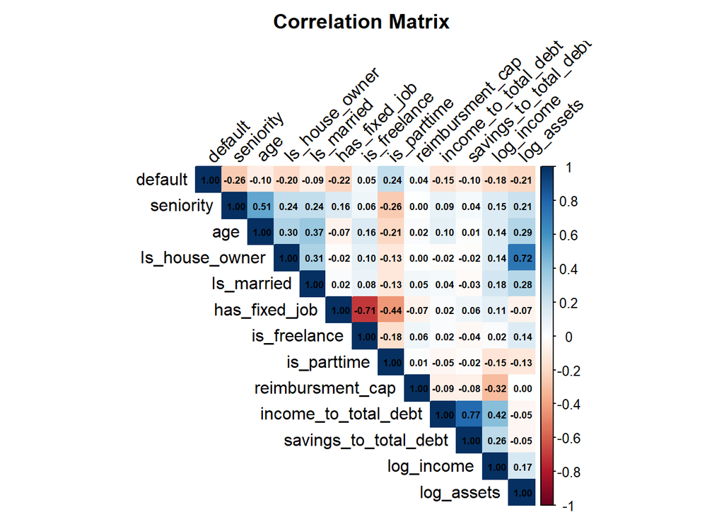

```r
vars <- c("default", "seniority", "age", "Is_house_owner","Is_married","has_fixed_job", "is_freelance", "is_parttime","reimbursment_cap", "income_to_total_debt","savings_to_total_debt","log_income", "log_assets")

cor_mat <- round(cor(df[, vars], use = "complete.obs"), 2)

corrplot(cor_mat,
         method = "color", type = "upper",
         addCoef.col = "black", number.cex = 0.55,
         tl.col = "black", tl.srt = 45,
         title = "Correlation Matrix", mar = c(0, 0, 2, 0))
```

# Model creation

## LPM model estimating

```r
LPM <- lm(default ~ seniority + age + Is_house_owner + Is_married + has_fixed_job + is_freelance + is_parttime + reimbursment_cap + income_to_total_debt + savings_to_total_debt + log_income + log_assets, df)
summary(LPM)
```

```
##
## Call:
## lm(formula = default ~ seniority + age + Is_house_owner + Is_married +
##     has_fixed_job + is_freelance + is_parttime + reimbursment_cap +
##     income_to_total_debt + savings_to_total_debt + log_income +
##     log_assets, data = df)
##
## Residuals:
##     Min      1Q  Median      3Q     Max
## -0.7831 -0.2948 -0.1436  0.3544  1.2686
##
## Coefficients:
##                         Estimate Std. Error t value Pr(>|t|)
## (Intercept)            0.6204866  0.0754642   8.222 2.60e-16 ***
## seniority             -0.0111059  0.0009330 -11.904  < 2e-16 ***
## age                    0.0043582  0.0007337   5.940 3.07e-09 ***
## Is_house_owner        -0.0588502  0.0179768  -3.274  0.00107 **
## Is_married             0.0080615  0.0155381   0.519  0.60391
## has_fixed_job         -0.0808852  0.0348745  -2.319  0.02042 *
## is_freelance           0.0483973  0.0355339   1.362  0.17327
## is_parttime            0.2056998  0.0387107   5.314 1.13e-07 ***
## reimbursment_cap       0.0011841  0.0055887   0.212  0.83221
## income_to_total_debt  -0.5803326  0.0813647  -7.132 1.15e-12 ***
## savings_to_total_debt  2.5318810  1.0355947   2.445  0.01453 *
## log_income            -0.0439741  0.0146801  -2.995  0.00276 **
## log_assets            -0.0158250  0.0021440  -7.381 1.87e-13 ***
## ---
## Signif. codes:  0 '***' 0.001 '**' 0.01 '*' 0.05 '.' 0.1 ' ' 1
##
## Residual standard error: 0.41 on 4433 degrees of freedom
## Multiple R-squared:  0.1701, Adjusted R-squared:  0.1679
## F-statistic: 75.73 on 12 and 4433 DF,  p-value: < 2.2e-16
```

## Logit model estimating

```r
logit <- glm(default ~ seniority + age + Is_house_owner + Is_married + has_fixed_job + is_freelance + is_parttime + reimbursment_cap + income_to_total_debt + savings_to_total_debt + log_income + log_assets, df, family = binomial(link = "logit"))
summary(logit)
```

```
##
## Call:
## glm(formula = default ~ seniority + age + Is_house_owner + Is_married +
##     has_fixed_job + is_freelance + is_parttime + reimbursment_cap +
##     income_to_total_debt + savings_to_total_debt + log_income +
##     log_assets, family = binomial(link = "logit"), data = df)
##
## Coefficients:
##                        Estimate Std. Error z value Pr(>|z|)
## (Intercept)            0.653878   0.435399   1.502 0.133151
## seniority             -0.080514   0.006802 -11.837  < 2e-16 ***
## age                    0.025749   0.004326   5.953 2.64e-09 ***
## Is_house_owner        -0.417654   0.108500  -3.849 0.000118 ***
## Is_married             0.057173   0.090183   0.634 0.526104
## has_fixed_job         -0.370176   0.189057  -1.958 0.050228 .
## is_freelance           0.353841   0.191305   1.850 0.064369 .
## is_parttime            0.905272   0.206746   4.379 1.19e-05 ***
## reimbursment_cap       0.007919   0.027655   0.286 0.774620
## income_to_total_debt  -5.125830   0.667692  -7.677 1.63e-14 ***
## savings_to_total_debt 22.102766   8.043937   2.748 0.006000 **
## log_income            -0.169223   0.088445  -1.913 0.055710 .
## log_assets            -0.086903   0.012387  -7.015 2.29e-12 ***
## ---
## Signif. codes:  0 '***' 0.001 '**' 0.01 '*' 0.05 '.' 0.1 ' ' 1
##
## (Dispersion parameter for binomial family taken to be 1)
##
##     Null deviance: 5280.3  on 4445  degrees of freedom
## Residual deviance: 4444.4  on 4433  degrees of freedom
## AIC: 4470.4
##
## Number of Fisher Scoring iterations: 5
```

## Probit estimating

```r
probit <- glm(default ~ seniority + age + Is_house_owner + Is_married + has_fixed_job + is_freelance + is_parttime + reimbursment_cap + income_to_total_debt + savings_to_total_debt + log_income + log_assets, df, family = binomial( link = "probit"))
summary(probit)
```

```
##
## Call:
## glm(formula = default ~ seniority + age + Is_house_owner + Is_married +
##     has_fixed_job + is_freelance + is_parttime + reimbursment_cap +
##     income_to_total_debt + savings_to_total_debt + log_income +
##     log_assets, family = binomial(link = "probit"), data = df)
##
## Coefficients:
##                        Estimate Std. Error z value Pr(>|z|)
## (Intercept)            0.412521   0.257339   1.603 0.108929
## seniority             -0.044213   0.003739 -11.823  < 2e-16 ***
## age                    0.015251   0.002536   6.014 1.81e-09 ***
## Is_house_owner        -0.231823   0.063046  -3.677 0.000236 ***
## Is_married             0.024032   0.053108   0.453 0.650904
## has_fixed_job         -0.238253   0.113453  -2.100 0.035726 *
## is_freelance           0.192282   0.115092   1.671 0.094787 .
## is_parttime            0.546775   0.124609   4.388 1.14e-05 ***
## reimbursment_cap       0.004681   0.017254   0.271 0.786159
## income_to_total_debt  -2.705312   0.364961  -7.413 1.24e-13 ***
## savings_to_total_debt 11.983653   4.434062   2.703 0.006879 **
## log_income            -0.114974   0.051695  -2.224 0.026142 *
## log_assets            -0.051704   0.007296  -7.087 1.37e-12 ***
## ---
## Signif. codes:  0 '***' 0.001 '**' 0.01 '*' 0.05 '.' 0.1 ' ' 1
##
## (Dispersion parameter for binomial family taken to be 1)
##
##     Null deviance: 5280.3  on 4445  degrees of freedom
## Residual deviance: 4454.2  on 4433  degrees of freedom
## AIC: 4480.2
##
## Number of Fisher Scoring iterations: 5
```

## Interpretation :

- *seniority* : negative coefficient as expected, significant at 99% level
- *age* : positive and significant at 99% level, meaning that the older is the client the higher is the higher is the default risk. May be due to bigger financial pressure due to children for age range 35 - 60 yo and less financial capacities for age range > 60 yo
- *Is_house_owner* : negative as expected, significant at 95% level of confidence
- *Is_married* : not significant, may be due to high financial pressure for families
- *has_fixed_job* : negative as expected, significant at 95% level of confidence
- *is_freelance* : not significant, being freelance may induce more volatility but is often related to higher incomes and more flexibility
- *is_parttime* : positive as expected, significant at 99% level of confidence *reimbursment_cap* : not significant, may be due to the fact that expenses changes when people loan money, so the reimbursment_cap ratio is not relevant anymore
- *income_to_total_debt* : negative and large meaning it has a big impact on the default capacity, which make sense because the risk of default is related to the value of the debt compared to the ability to reimburse this debt
- *savings_to_total_debt* : surprisingly positive, may be due to colinearity with income_to_total_debt
- *log_income* and *log_asset* : both negative and significant at 95% level of confidence

# Application of the model to 10 personas

We will know use the 3 models created to estimate the probabilities of default of 10 clients that asked for a loan.

## Data Preparation

```r
to_predict <- read.csv("raw_data/prospects.csv",stringsAsFactors = TRUE)
summary(to_predict)
```

```
##        prospect   seniority         home        age             marital
##  Beckmann  :1   Min.   : 0.0   owner  :7   Min.   :23.00   married  :7
##  Buntschuh :1   1st Qu.: 2.0   parents:1   1st Qu.:27.75   separated:1
##  Fassbender:1   Median : 4.0   rent   :2   Median :32.50   single   :2
##  Ginter    :1   Mean   : 6.1               Mean   :36.20
##  Heckmann  :1   3rd Qu.: 9.5               3rd Qu.:45.50
##  Kremer    :1   Max.   :19.0               Max.   :56.00
##  (Other)   :4
##         job       expenses         income          assets
##  fixed    :4   Min.   :35.00   Min.   :  101   Min.   :     0
##  freelance:5   1st Qu.:37.50   1st Qu.:  150   1st Qu.:  6000
##  partime  :1   Median :60.00   Median :  286   Median : 11250
##                Mean   :58.50   Mean   : 1608   Mean   : 50000
##                3rd Qu.:71.25   3rd Qu.:  395   3rd Qu.: 18375
##                Max.   :90.00   Max.   :13700   Max.   :400000
##
##       debt            amount          savings
##  Min.   :   0.0   Min.   : 370.0   Min.   :-0.300
##  1st Qu.:   0.0   1st Qu.: 781.2   1st Qu.: 2.801
##  Median :   0.0   Median : 950.0   Median : 4.100
##  Mean   : 585.0   Mean   : 944.5   Mean   : 4.068
##  3rd Qu.: 462.5   3rd Qu.:1150.0   3rd Qu.: 5.287
##  Max.   :4000.0   Max.   :1550.0   Max.   : 7.824
##
```

```r
to_predict$Is_house_owner <- as.numeric(to_predict$home == "owner")
to_predict$Is_married <- as.numeric(to_predict$marital == "married")
to_predict$has_fixed_job <- as.numeric(to_predict$job == "fixed")
to_predict$is_freelance <- as.numeric(to_predict$job == "freelance")
to_predict$is_parttime <- as.numeric(to_predict$job == "partime")
to_predict$reimbursment_cap <- to_predict$expenses/to_predict$income
to_predict$income_to_total_debt <- to_predict$income/(to_predict$debt+to_predict$amount)
to_predict$savings_to_total_debt <- to_predict$savings/(to_predict$debt+to_predict$amount)
to_predict$log_income <- log(1 + to_predict$income)
to_predict$log_assets <- log(1 + to_predict$assets)

to_predict = to_predict[,c("seniority","age","Is_house_owner","Is_married","has_fixed_job","is_freelance","is_parttime","reimbursment_cap","income_to_total_debt","savings_to_total_debt","log_income","log_assets","amount","prospect")]
```

Predict the probabilities for the prospect using the three different models

```r
to_predict$p_LPM <- pmin(1,pmax(0, predict(LPM, newdata = to_predict)))
to_predict$p_logit <- predict(logit, newdata = to_predict, type = "response" )
to_predict$p_probit <- predict(probit, newdata = to_predict, type = "response")
```

## Models estimated probabilities comparison :

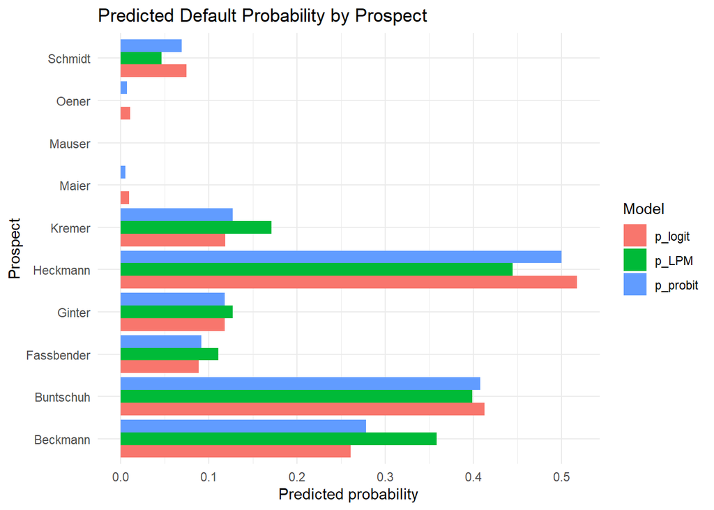

```r
probabilities <- to_predict %>%
  select(prospect, p_LPM, p_logit, p_probit) %>%
  pivot_longer(
    cols = c(p_LPM, p_logit, p_probit),
    names_to = "Model",
    values_to = "Probability"
  )

probabilities_comparison_plot <- ggplot(probabilities,
       aes(x = prospect, y = Probability, fill = Model)) +
  geom_col(position = "dodge") +
  coord_flip() +
  labs(
    title = "Predicted Default Probability by Prospect",
    x = "Prospect",
    y = "Predicted probability",
    fill = "Model"
  ) +
  theme_minimal()

print(probabilities_comparison_plot)
```

```r
ggsave( filename = "Output_plots/probabilities_comparison.png", plot = probabilities_comparison_plot , width = 9, height = 6, dpi = 300 )
```

# Application of the result to a 1- year loan 10% IR

We will know consider they asked for a 1-year loan with 10% interest rate, considering no cost of borrowing and no other variable costs :

Earning without default :
$$\begin{aligned} Earning \ without \ default = \;& 0.10 * Loan \
amount
\end{aligned}$$

```r
to_predict$earning_wo_default <- 0.10 * to_predict$amount
```

Expected earnings : *using the law of total probability*
$$\begin{aligned} Expected \ earning = \;& ( 1 - p_{default} ) *
Earning \ without \ default \ - \ p_{default} \ * \ Loan \ amount
\end{aligned}$$

```r
to_predict$expected_earning <- (1 - to_predict$p_LPM) * to_predict$earning_wo_default - to_predict$p_LPM * to_predict$amount
```

A loan is accepted if the expected earning is positive

```r
# if loan accepted : Final decision = 1
# if loan refused : Final decision = 0
to_predict$final_decision <- as.numeric(to_predict$expected_earning > 0)

print(str_glue("Number of accepted loan : {sum(to_predict$final_decision)}"))
```

```
## Number of accepted loan : 4
```

```r
accepted_loan_names_list <- to_predict[to_predict$final_decision == 1,"prospect"]

print(str_glue("Accepted loan names list : {accepted_loan_names_list}"))
```

```
## Accepted loan names list : Maier
## Accepted loan names list : Mauser
## Accepted loan names list : Schmidt
## Accepted loan names list : Oener
```

The expected total profit would be :

```r
total_expected_earning = sum(as.numeric(to_predict$final_decision) * to_predict$expected_earning)

print(str_glue("expected earning : {round(total_expected_earning,2)} $"))
```

```
## expected earning : 281.97 $
```

### Summary of the decision :

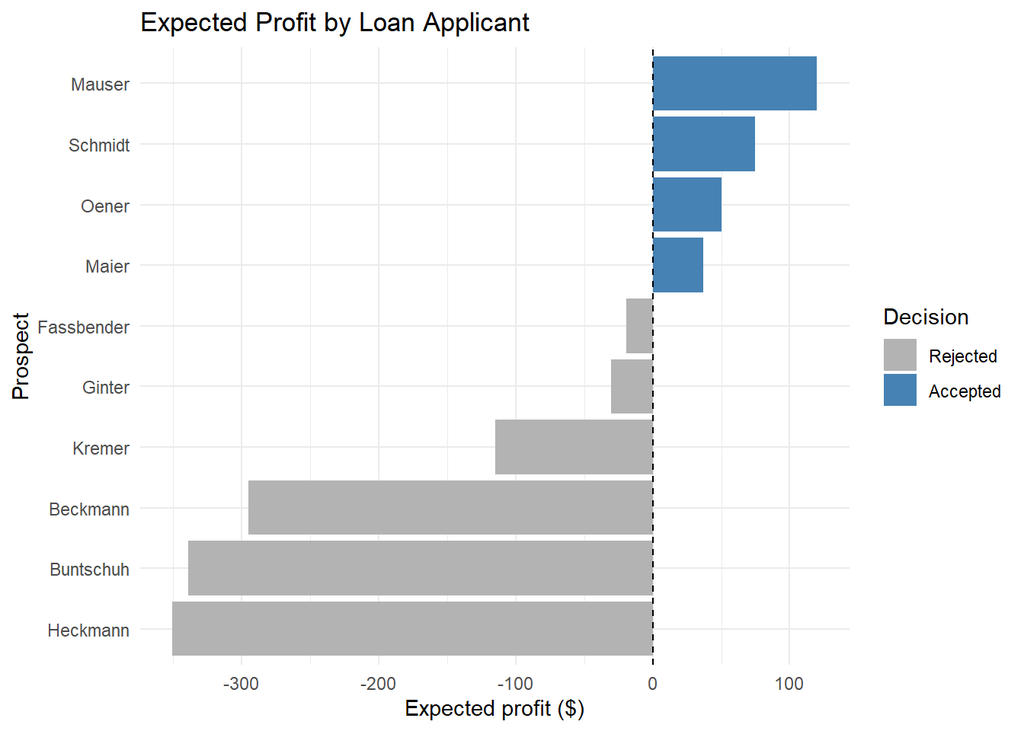

```r
expected_profit_by_prospect <- ggplot(to_predict,
       aes(x = reorder(prospect, expected_earning),
           y = expected_earning,
           fill = factor(final_decision))) +
  geom_col() +
  coord_flip() +
  geom_hline(yintercept = 0, linetype = "dashed") +
  scale_fill_manual(
    values = c("0" = "grey70", "1" = "steelblue"),
    labels = c("0" = "Rejected", "1" = "Accepted")
  ) +
  labs(
    title = "Expected Profit by Loan Applicant",
    x = "Prospect",
    y = "Expected profit ($)",
    fill = "Decision"
  ) +
  theme_minimal()

print(expected_profit_by_prospect)
```

```r
ggsave( filename = "Output_plots/expected_profit_by_prospect.png", plot = expected_profit_by_prospect , width = 9, height = 6, dpi = 300 )
```

### Bad Scenario

To limit the risk at the maximum we can use the upper bound of the probability interval

```r
#predict probability with prediction interval
prediction_interval <- predict(LPM,newdata = to_predict,interval="prediction",level = 0.95
)
to_predict$Bad_Scn_p_LPM <- pmin(1,pmax(0, prediction_interval[, "upr"]))

#compute expected earning
to_predict$Bad_Scn_expected_earning <- (1 - to_predict$Bad_Scn_p_LPM) * to_predict$earning_wo_default - to_predict$Bad_Scn_p_LPM * to_predict$amount

#compute final decision
to_predict$Bad_Scn_final_decision <- as.numeric(to_predict$Bad_Scn_expected_earning > 0)

print(str_glue("Number of accepted loan : {sum(to_predict$Bad_Scn_final_decision)}"))
```

```
## Number of accepted loan : 1
```

```r
Bad_Scn_accepted_loan_names_list <- to_predict[to_predict$Bad_Scn_final_decision == 1,"prospect"]

#compute total expected earning
Bad_Scn_total_expected_earning = sum(as.numeric(to_predict$Bad_Scn_final_decision) * to_predict$Bad_Scn_expected_earning)

print(str_glue("Accepted loan names list : {Bad_Scn_accepted_loan_names_list}"))
```

```
## Accepted loan names list : Mauser
```

```r
print(str_glue("expected earning : {round(Bad_Scn_total_expected_earning,2)} $"))
```

```
## expected earning : 120 $
```

### Visual comparison between bad scenario and baseline

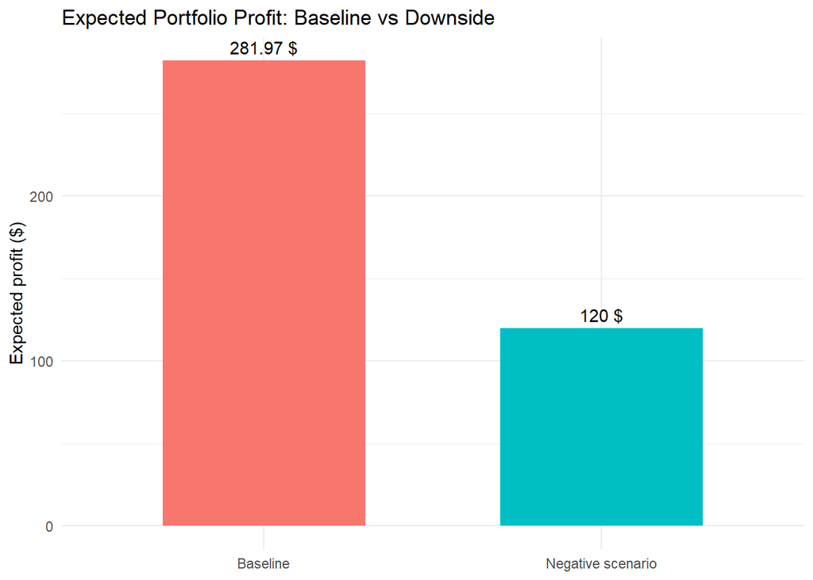

```r
scenario_results <- data.frame(
  Scenario = c("Baseline", "Negative scenario"),
  Expected_Profit = c(
    total_expected_earning,
    Bad_Scn_total_expected_earning
  )
)

scenarii_comparison <- ggplot(scenario_results,
       aes(x = Scenario, y = Expected_Profit, fill = Scenario)) +
  geom_col(width = 0.6) +
  geom_text(
    aes(label = paste0(round(Expected_Profit, 2), " $")),
    vjust = -0.5
  ) +
  labs(
    title = "Expected Portfolio Profit: Baseline vs Downside",
    x = NULL,
    y = "Expected profit ($)"
  ) +
  theme_minimal() +
  theme(legend.position = "none")

print(scenarii_comparison)
```

```r
ggsave( filename = "Output_plots/scenarii_comparison.png", plot = scenarii_comparison , width = 9, height = 6, dpi = 300 )
```